# Analysis of version 3 simulations

Gibran Hemani

15/06/2017

Approximately 200,000 simulations have been performed of x associating with y, simulating different samples for x and y phenotypes and extracting the relevant SNPs from each to make a 2-sample MR analysis. Simulations are performed with the following variables. The causal and reverse causal effects were estimated using Rucker, median and mode estimators

- Sample size of x and y
- Number of instruments for x
- Number of instruments for y
- Number of confounders
- Number of instruments per confounder
- Causal effect of x on y (sometimes 0)
- Causal effects of confounders on x and y
- Variance explained by x instruments on x
- Variance explained by y instruments on y
- Proportion of instruments exhibiting pleiotropy
- Variance explained by x instruments on y and vice versa
- Effect of directional pleiotropy

Instruments for each MR test were selected either by

- Top hits (significant hits for the exposure)
- Steiger (rsq snp-exposure > rsq snp-outcome)
- Heterogeneity outliers (Qpval > 0.05)
- Steiger and then heterogeneity

Then the following tests were performed

- Mean (simple, ivw fe, egger fe, ivw re, egger re)
- Median (simple, weighted, penalised)
- Mode (simple, weighted, penalised)

This gives 44 methods in total.

## Simulations

A broad range of simulations are performed, where instruments are a mixture of direct effects (with pleiotropic effects on y), reverse effects (with pleiotropic effects on x) and confounder effects that act through u on x and y. If we break down the proportion of a SNP’s effect that is valid (i.e. for all effects on x and y, what proportion is acting on x), for only detected variants in a simulation - this is what it looks like

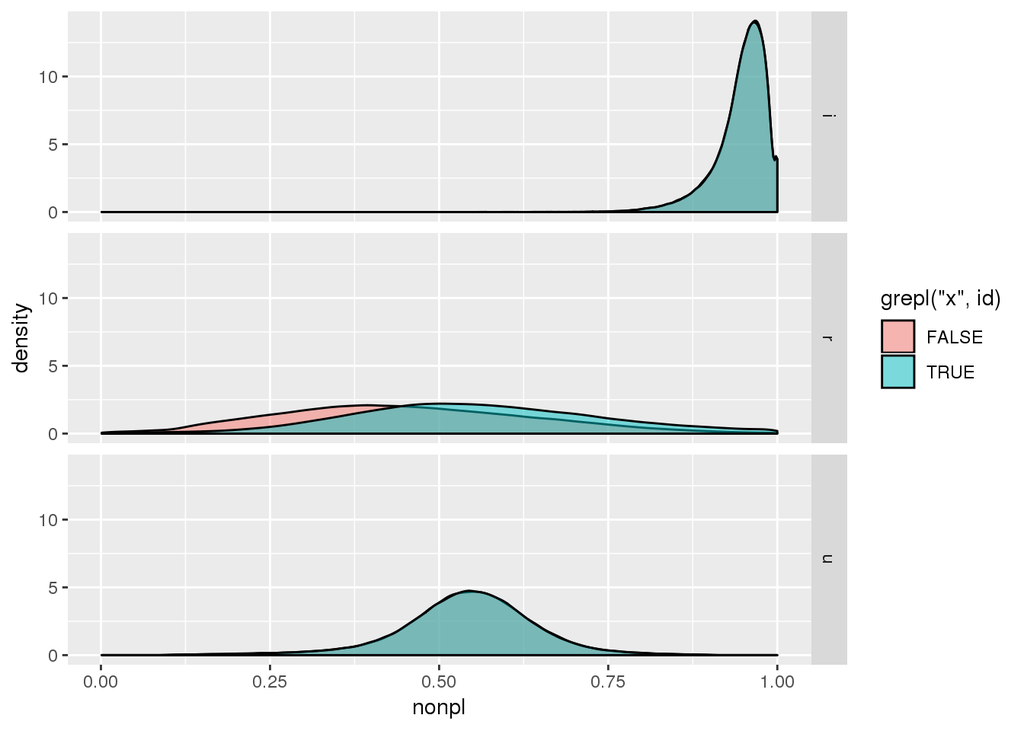

```r
load("../results/sim3/agg-plei_summary.rdata")
ggplot(plei_summary, aes(x=nonpl)) +
geom_density(aes(fill=grepl("x", id)), alpha=0.5) +
facet_grid(w ~ .)
```

Note that for analyses of y on x the level of pleiotropy is slightly higher because there is a set of SNPs that influence x, which influences y. The only way that reverse causal SNPs can arise for x is if they have pleiotropic effects.

These are the distributions of estimated heterogeneity Isq from the simulations

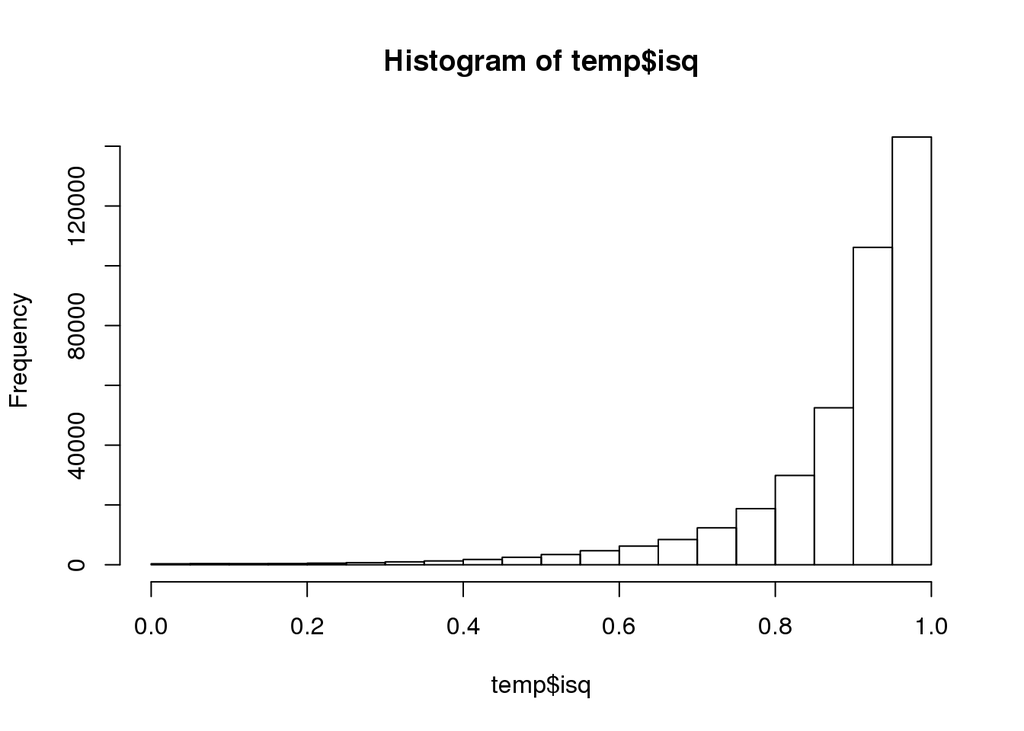

```r
load("../results/sim3/agg-heterogeneity.rdata")
load("../results/sim3/agg-plei_summary.rdata")

temp <- subset(heterogeneity, method == "IVW" & !steiger_filtered & !outlier_filtered & selection == "o")

temp$isq <- (temp$Q - temp$df -1) / temp$Q
temp <- subset(temp, isq >= 0)
hist(temp$isq)
```

Are there many simulations with low heterogeneity?

```r
table(temp$pval < 0.05)
```

```
##
##  FALSE   TRUE
##   1758 393043
```

What is the relationship between isq and simulated levels of pleiotropy?

```r
plei <- group_by(plei_summary, id) %>%
    summarise(nonpl = sum(nonpl * effd / sum(effd)))

temp$id <- paste0(temp$id, temp$hypothesis)
temp <- inner_join(temp, plei, by="id")

summary(lm(nonpl ~ isq, temp))
```

```
##
## Call:
## lm(formula = nonpl ~ isq, data = temp)
##
## Residuals:
##      Min       1Q   Median       3Q      Max
## -0.39587 -0.05840  0.00661  0.06451  0.21287
##
## Coefficients:
##               Estimate Std. Error t value Pr(>|t|)
## (Intercept)  0.8188229  0.0009892  827.75   <2e-16 ***
## isq         -0.0363639  0.0011061  -32.88   <2e-16 ***
## ---
## Signif. codes:  0 '***' 0.001 '**' 0.01 '*' 0.05 '.' 0.1 ' ' 1
##
## Residual standard error: 0.089 on 391438 degrees of freedom
##   (3361 observations deleted due to missingness)
## Multiple R-squared:  0.002754,   Adjusted R-squared:  0.002751
## F-statistic:  1081 on 1 and 391438 DF,  p-value: < 2.2e-16
```

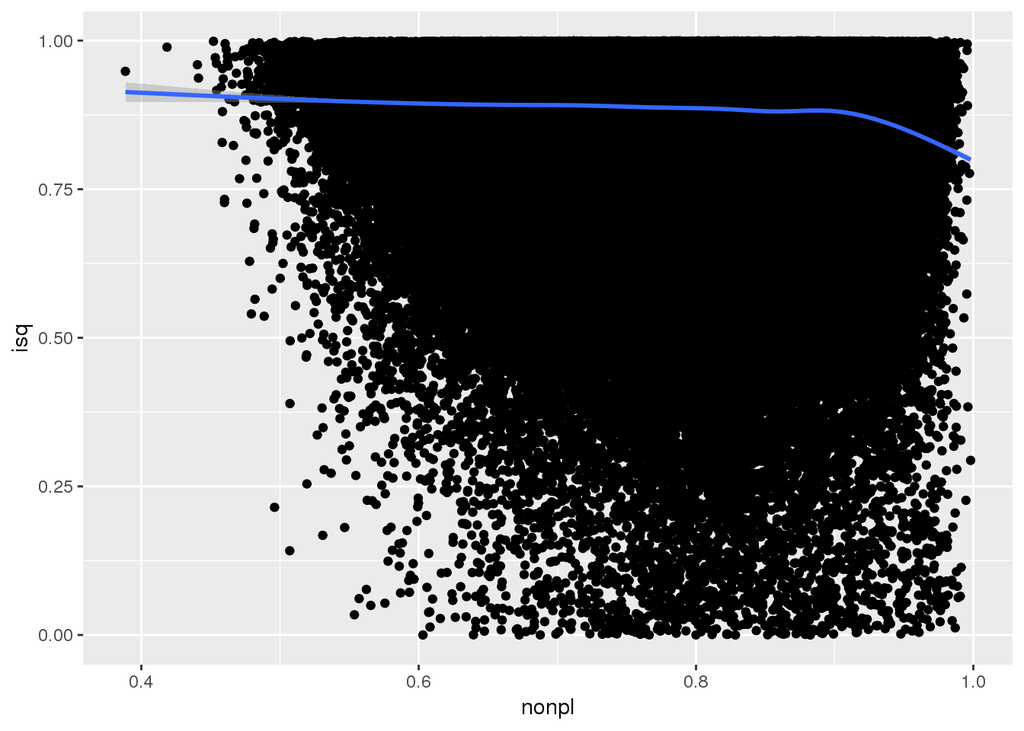

```r
ggplot(temp, aes(x=nonpl, y=isq)) +
geom_point() +
geom_smooth()
```

## Analysis

Define the performance of a method as its ability to detect true positives (sensitivity) and true negatives (specificity). Estimate AUROC for each method / strategy combination. Hypothesis is that under different circumstances different methods will perform better or worse.

First example: overall across all simulations how good are the methods at discriminating?

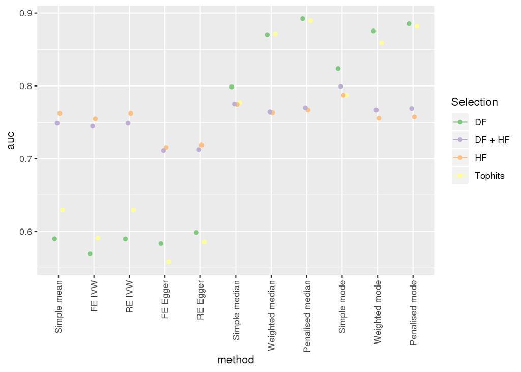

```r
load("rocs.rdata")
p1 <- ggplot(rocs, aes(x=method, y=auc, group=strategy, colour=strategy)) +
geom_point(position=position_dodge(width=0.3)) +
geom_errorbar(width=0, position=position_dodge(width=0.3), aes(ymin=ci_lo, ymax=ci_up)) +
theme(axis.text.x=element_text(angle=90)) +
scale_colour_brewer(type="qual") +
labs(colour="Selection") +
theme(axis.text.x=element_text(hjust=1, vjust=0.5))
p1
```

```r
ggsave(p1, file="../images/rocs1.pdf")
```

Now calculate AUROC for different classes of simulation

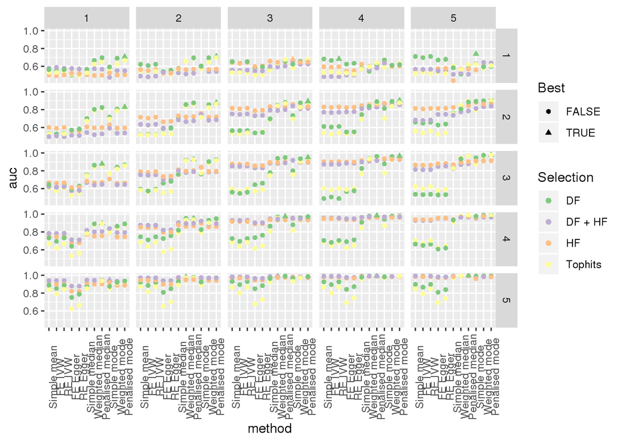

```r
x <- rocs2 %>%
group_by(nsnpbin, pbin) %>%
arrange(desc(auc)) %>%
slice(1)

rocs2$top <- FALSE
rocs2$top[paste(rocs2$method, rocs2$strategy, rocs2$pbin, rocs2$nsnpbin) %in% paste(x$method, x$strategy, x$pbin, x$nsnpbin)] <- TRUE

p1 <- ggplot(rocs2, aes(x=method, y=auc, group=strategy, colour=strategy, shape=top)) +
geom_point() +
facet_grid(pbin ~ nsnpbin) +
theme(axis.text.x=element_text(angle=90)) +
scale_colour_brewer(type="qual") +
labs(colour="Selection", shape="Best")
p1
```

```r
ggsave(p1, file="../images/rocs2.pdf")
```

Can we demonstrate that across different simulation scenarios there are different methods that perform most accurately, thereby necessitating some automated way of choosing the most reliable method?

```r
y <- rocs2 %>% as_data_frame() %>%
group_by(nsnpbin, pbin) %>%
arrange(desc(auc)) %>%
mutate(rank=1:n(), method=as.factor(method))
y[y$rank == 1,] %>% {table(.$method, .$strategy)}
```

```
##
##                    DF DF + HF HF Tophits
##   Simple mean       0       0  0       0
##   FE IVW            0       0  0       0
##   RE IVW            1       0  0       0
##   FE Egger          0       0  0       0
##   RE Egger          0       0  0       0
##   Simple median     0       0  0       0
##   Weighted median   2       0  0       0
##   Penalised median  8       0  0       0
##   Simple mode       1       1  1       0
##   Weighted mode     0       0  0       0
##   Penalised mode    9       0  0       2
```

We find that 4 out of 4 instrument selection strategies appear in the list of top performing methods, and 5 of the 11 methods also.

## Summary set metrics

Can the summary set metrics predict the pleiotropy of a model?

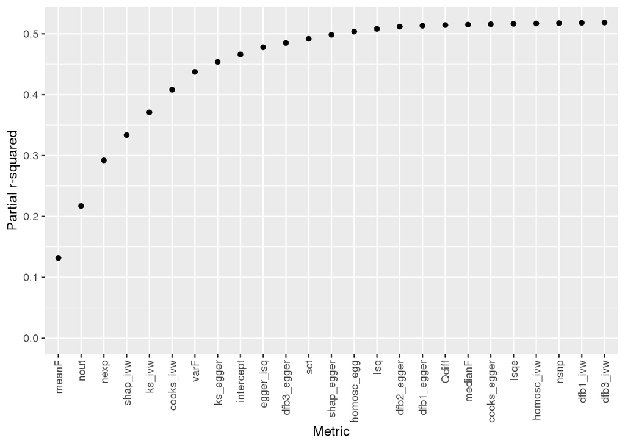

```r
load("../results/sim3/agg-info.rdata")
info <- subset(info, selection == "e")

info2 <- subset(info, !steiger_filtered & !outlier_filtered) %>% mutate(id=paste0(id, hypothesis))

info2 <- inner_join(info2, plei, by=c("id"))
out <- summary(lm(nonpl ~ ., subset(info2, select=-c(id.exposure, id.outcome, id, hypothesis, selection, steiger_filtered, outlier_filtered))))
o <- out$coef %>% as_data_frame %>%
    mutate(var = rownames(out$coef), f=`t value`^2, rsq=f/(f+out$df[2]-2)) %>% slice(-1) %>%
    arrange(desc(f))
o$var <- as.factor(o$var)
o$var <- factor(o$var, levels=as.character(o$var))
p1 <- ggplot(o, aes(x=var, y=cumsum(rsq*out$r.squared/sum(rsq)))) +
geom_point(stat="identity") +
theme(axis.text.x=element_text(angle=90, hjust=1, vjust=0.5)) +
ylim(0, out$r.squared) +
labs(y="Partial r-squared", x="Metric")
p1
```

```r
ggsave(p1, file="../images/info_plei.pdf")
```

The metrics have an explanatory power adjusted r-square of 0.518352 of the pleiotropic value of the simulations. This opens the possibility that the summary stats themselves can explain a substantial proportion of the variance, and therefore be predictive of the model to use.